# 🍄 Mushroom Edibility: Explainable Predictions

## 2. Feature importance: Decision Tree vs. Random Forest vs. LightGBM

Do simple and complex models agree on what matters? Comparing importance rankings side by side is itself a form of explainability — if a fast, fully-grown Decision Tree and a 150-tree Random Forest broadly agree, that's reassuring; if they diverge, it's worth digging into why.

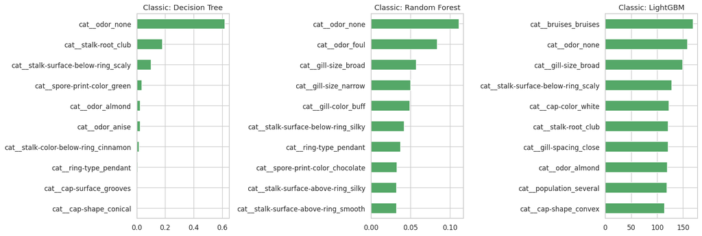

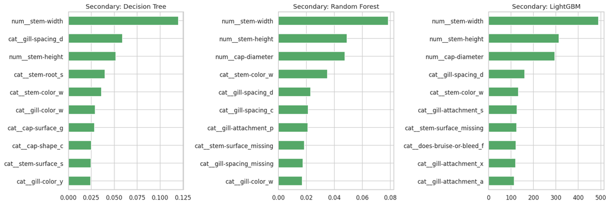

```python
def top_importances(model, feature_names, n=10):
    imp = pd.Series(model.feature_importances_, index=feature_names)
    return imp.sort_values(ascending=False).head(n)

for name, d in datasets.items():
    full_tree = DecisionTreeClassifier(random_state=RANDOM_STATE)
    full_tree.fit(d["X_train"], d["y_train"])

    rf = RandomForestClassifier(n_estimators=150, random_state=RANDOM_STATE, n_jobs=-1)
    rf.fit(d["X_train"], d["y_train"])

    lgbm = LGBMClassifier(n_estimators=200, random_state=RANDOM_STATE, n_jobs=-1, verbose=-1)
    lgbm.fit(d["X_train"], d["y_train"])

    d["full_tree"], d["rf"], d["lgbm"] = full_tree, rf, lgbm

    fig, axes = plt.subplots(1, 3, figsize=(16, 5.5))
    for ax, (mname, model) in zip(axes, [("Decision Tree", full_tree), ("Random Forest", rf), ("LightGBM", lgbm)]):
        top = top_importances(model, d["feature_names"])
        top.iloc[::-1].plot.barh(ax=ax, color="#55A868")
        ax.set_title(f"{name}: {mname}")
    plt.tight_layout()
    plt.show()
```

## 3. SHAP: global feature impact

SHAP values quantify each feature's contribution to individual predictions, then aggregate into a global importance measure — computed here on the LightGBM model for each dataset, on a 300-row sample of the held-out test set for speed.

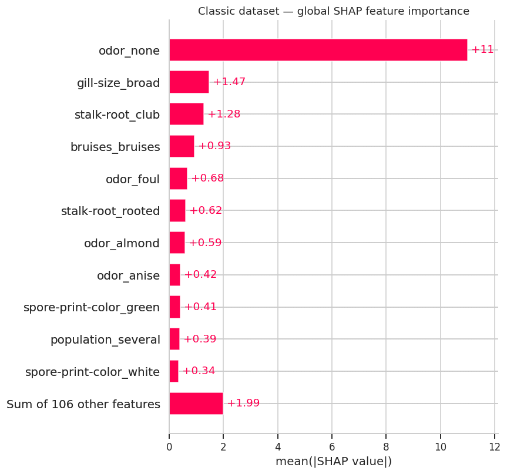

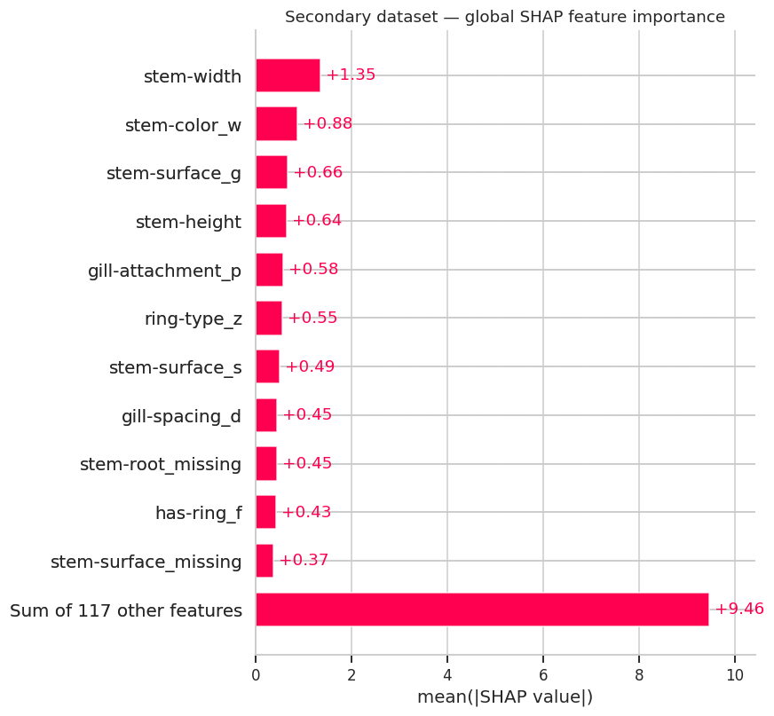

```python
shap_samples = {}
for name, d in datasets.items():
    X_te_dense = d["X_test"][:300].toarray() if hasattr(d["X_test"], "toarray") else d["X_test"][:300]
    explainer = shap.TreeExplainer(d["lgbm"])
    sv = explainer(X_te_dense)
    sv.feature_names = [f.replace("num__", "").replace("cat__", "") for f in d["feature_names"]]
    shap_samples[name] = sv

    plt.figure()
    shap.plots.bar(sv, max_display=12, show=False)
    plt.title(f"{name} dataset — global SHAP feature importance")
    plt.tight_layout()
    plt.show()
```